# Chapter C13

# 疲労

By Clarence R. Smith

## C13.1 はじめに

金属に関する疲労の問題は、1世紀以上にわたって実験的に研究されてきた。1849年、JonesとGaltonは曲げを受ける鋳鉄棒を調査した。彼らは、極限曲げ強さの3分の1を超える荷重が負荷された場合、10万回未満のサイクルで破壊が発生することを発見した。Fairbornによる錬鉄製の組立桁に関する同様の研究（1860〜1861年）でも、同様の結果が示された。プロイセン国鉄のためのWöhlerの研究は1850年代にまで遡り、彼は引張と圧縮の繰り返し直接荷重、繰り返しの曲げ荷重、および繰り返しのねじり荷重を受けるさまざまなグレードの鉄および鋼の広範な一連の試験を実施した。

過去の航空機は、今日の高速航空機が経験するような荷重を受けることはなかった。また、それらは静的強度要件を満たすために、実用荷重による応力が自動的に適切な疲労寿命を提供する範囲に収まるほど引張強度が低い材料で造られていた。

疲労の問題は、今日の航空機において驚くべき速度で台頭してきた。これは、今日の航空機が、かつて使用されていたものよりも強度は高いが、疲労特性はそれと同等（場合によってはそれ以下）の材料で造られているためである。その結果、実用中の破壊が蓄積し、中には致命的な事故を伴うものもあった。このような状況により、設計者は不慣れな分野に関与せざるを得なくなった。さらに、より正確な応力解析手法により、構造物をより高い効率と精度で設計できるようになった。これにより、作動応力は従来限界値と指定されていたものに一段と近づくことになった。実際、戦闘機の仕様では設計限界荷重の最大1.25倍での疲労サイクルが要求され、輸送機は限界荷重の1.05倍で試験される。

完全に滑らかな高速道路を走行中に自動車の車軸の破損を経験したことのある人は、疲労破壊が必ずしも突然の過荷重や、平均よりわずかに高いだけの荷重によって引き起こされるわけではないことを理解している。破損した部品をその後に検査すると、疲労破壊に伴う特有のストライエーション（条痕）すなわち「ビーチマーク（貝殻状変化）」が明らかになる。これは、疲労には常にそのような模様が伴うというわけではないが、通常はそうであることを示している。航空機のリムの典型的な疲労破壊を図C13.1に示す。ストライエーションは、アールの最も応力の高い領域から始まり、外側に向かって進行し、目立つリップで示される最終的な静的破壊に至っていることに注意されたい。

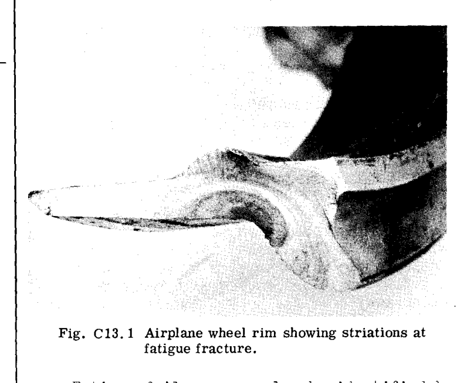

図C13.1 疲労破面にストライエーションを示す航空機ホイールリム

疲労破壊は、破面における結晶の明瞭な視認性によっても特定できる。これは、金属が「結晶化」してしまったという古い信念の主な原因となっている。しかし、この外観は、静的破壊の粒界破壊（「結晶粒界に沿った破壊」）とは対照的に、疲労破壊が結晶を直接横切る「経結晶破壊」であるためである。どちらのタイプの破壊も金属結晶を伴い、疲労破壊における結晶の方がより明確で視認しやすいという事実があるものの、一方が他方よりも必ずしも結晶性であるというわけではない。

疲労破壊は、き裂発生の焦点となる何らかの不連続部から発生する。これらは応力集中と呼ばれる。しかし、き裂が生じる前に、「転位」と呼ばれる原子の配列の乱れが結晶粒界に沿って堆積し、最終的に侵入して疲労き裂を引き起こす傾向がある。これは非常に初期の段階で発生するが、目に見える「工学的」なき裂は、通常、破断までの寿命の50%以上が消費されるまで発生しない。

しかし、特別な表面処理や残留圧縮応力が導入されない限り、き裂は常に表面から発生する。

## C13.2 応力集中

応力集中がなければ、本章を書く必要はなかったであろう。これは、静的設計で使用される原則が、実用荷重によって課される応力を補償するのに十分であるためである。あいにく、応力集中は存在するため、疲労に取り組む前にこの主題についての議論が必要となる。

応力集中係数は、実際の応力を明らかにするために、不連続部から離れた公称応力に乗じる係数として定義される。ハンドブックの値は、一部の値が公称総面積応力に基づいているのに対し、他の値は最小断面を通る純面積に基づいているという点で異なる場合がある。したがって、中央に1/4インチ径の穴があけられた幅1インチの引張試験片がある場合、穴から離れた断面を通る応力に基づくと、その集中係数は3.2になる。しかし、穴を通る純面積に基づくと、集中は2.4になる。

同一の形状および荷重条件であっても、ハンドブックの応力集中の値が異なる場合がある。これは、あるものは数学的に導き出されたものである一方、他のものは光弾性や他の実験的応力解析技術を用いて実験的に導き出されたものであるためかもしれない。広い板の穴の縁における集中に対して評価される一般的な値は3である。明らかに、板幅に対して穴のサイズが大きくなるにつれて、総面積応力に基づく集中は大きくなる。ピン荷重を受ける穴の応力集中は、広い板の中の極めて小さなピンに対する無限大から、板が穴径の2.5倍である場合の約4.5まで、そして穴径が板の幅に非常に近づく場合はより高い値まで変化し得る。これは、引張荷重を受ける板におけるピン荷重を受ける穴および荷重を受けない穴の応力集中を示す図C13.2に示されている。ここでは、穴から離れた総面積応力の観点から、ラグの集中は $a/b$ 比が約0.4（穴径の2.5倍）のときに最も小さくなることがわかる。ここで、 $a$ は穴径、 $b$ はラグ幅である。機械的に締結された継手は本質的にいくつかのラグが並んだものであるため、最適なファスナー間隔は約2.5径になる。このような継手は、

$$\left( \frac{\text{net area}}{\text{gross area}} \right)$$

の効率が0.6となる。これは、少なくとも0.75の継手効率が要求される静的設計とは一致しない。

明らかに、ラグを設計する場合、多くのラグ（ロッドエンドなど）にはショルダーを通る部分と主径を通る部分の2つの臨界領域があるため、総面積の観点から応力集中を使用することは適用できない。したがって、通常は純応力を扱い、図C13.3に示すような集中係数を使用する。

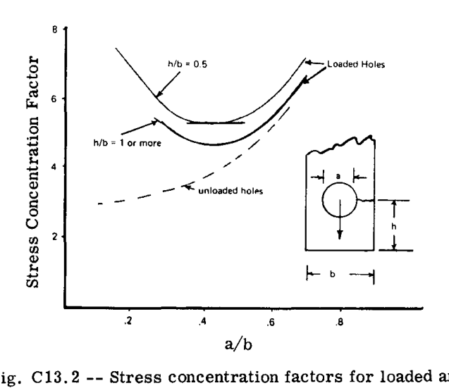

図CI3.2 引張応力を受ける板の荷重を受ける穴および荷重を受けない穴の応力集中係数。Frocht & Hillの著作から総面積応力に適合させた。 (2)

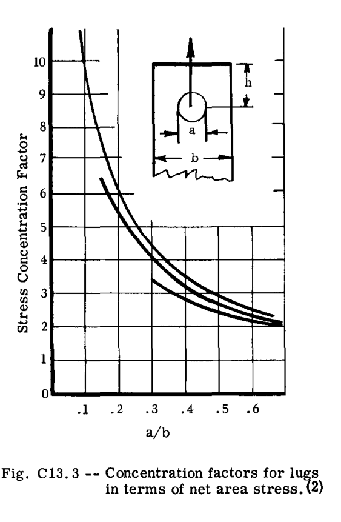

図CI3.3 純面積応力の観点から見たラグの集中係数。 (2)

鋭いエッジノッチを伴うほぼすべてのケースにおいて、応力勾配は非常に急である。これは、引張荷重を受ける広い板の鋭いエッジノッチによって生じる光弾性パターンによって図C13.4に示されている。ここでは、暗い線（フリンジ）の数は応力に直接比例している。これはさらに、引張荷重を受ける広い板の穴の縁からの応力勾配が穴の縁からの半径の観点から与えられている図C13.5に示されている。

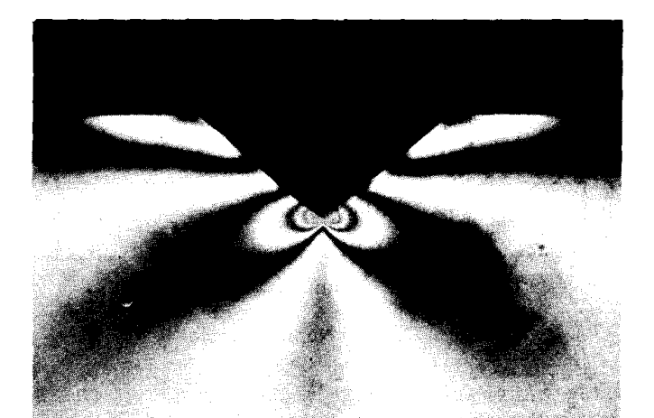

図CI3.4 鋭いエッジノッチの光弾性パターン

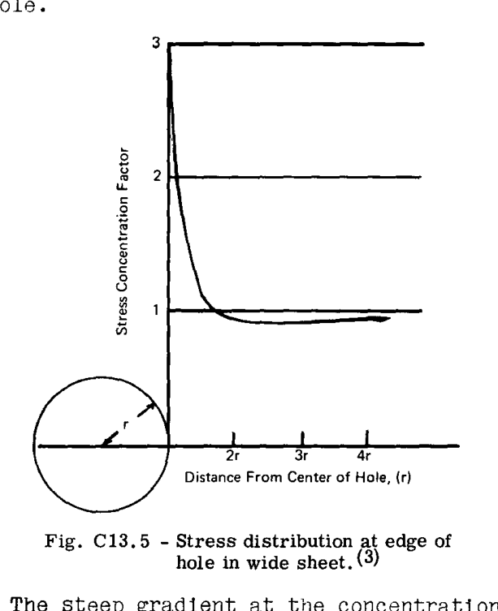

図CI3.5 広い板の穴の縁における応力分布。 (3)

集中部における急な勾配は、集中部から少し離れた応力を犠牲にして、集中部における応力を操作できるという点で特に重要である。したがって、ショットピーニング、表面窒化などの実務があり、これらは集中部における応力をより好ましい場所にシフトさせる。

その他の幾何学的応力集中は、図C13.6、13.7、および13.8に示されている。「幾何学的応力集中」という用語は、ここでは「疲労応力集中係数」という用語と区別するために使用されている。疲労応力集中係数は、多かれ少なかれ、同じ寿命および荷重条件下における、切欠きのない試験片の応力に対する、切欠きのある試験片の応力の比から導き出される架空の値である。これについては後で詳しく説明する。

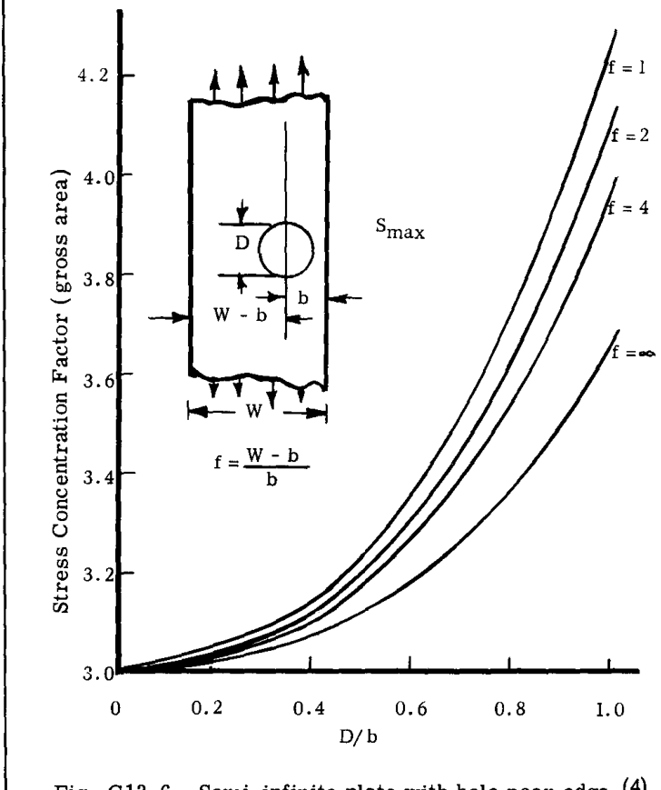

図CI3.6 縁の近くに穴のある半無限板。 (4)

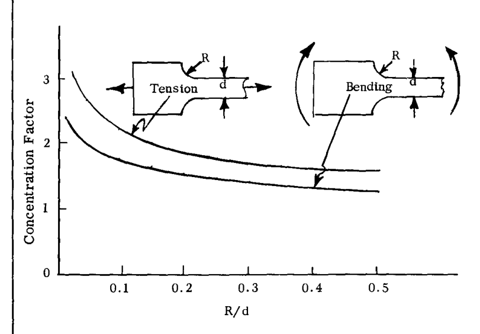

図CI3.7 フィレット付き矩形板。 (5)

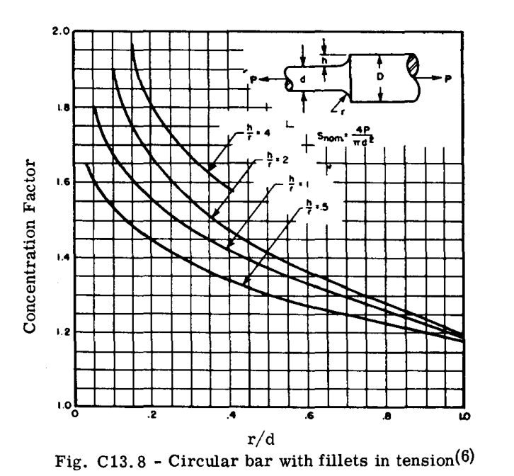

図C13.8 引張を受けるフィレット付き丸棒 (6)

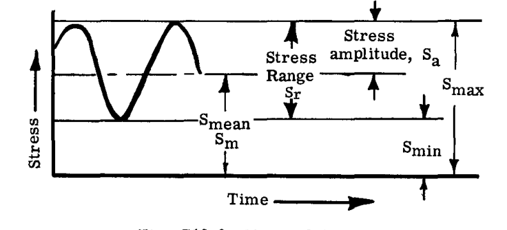

図C13.9 命名法

## C13.3 疲労データ

### C13.3.1 切欠きなしデータ

疲労における切欠きなしデータは、標準的な引張試験片によって決定される静的特性に匹敵する。静的な応力-ひずみ曲線が静的特性を表すように、S-N曲線は基本的な疲労特性を表す。ここで「基本」という用語は、与えられた材料の基本的な特性を指定するために使用される。これは、残留機械加工応力が結果に10倍以上影響を与える可能性があり、それによって基本的な材料特性の領域から排除される、切欠きのある試験片のS-Nデータとは一致しない。 $\varepsilon$ -N曲線の方がさらに基本であると主張されるかもしれないが、ハンドブックでより入手しやすいため、S-Nデータを使用する。

静的特性は引張および/または圧縮の降伏強さおよび極限強さの観点から提示されるが、疲労データは多くの任意の中間値および荷重の態様に対して提示される。記述を容易にするために、応力比（R）という用語が使用され、その定義は $R = S_{\min}/S_{\max}$ である。したがって、0から最大応力までの荷重の場合、応力比 $R$ は $0/S_{\max} = 0$ となる。両振り荷重の場合、 $S_{\min}$ は $S_{\max}$ と等しく逆符号であり、その場合 $R = -1$ となる。従来の実験室での疲労試験の命名法を図C13.9に示す。7075-T6アルミニウム合金のS-N曲線のファミリーを図C13.10に示す。ここで、実線は軸荷重を受ける厚さ0.1インチの薄板材料の平均（対数平均）値を表す。破線は、中間値の推定を助けるための補間である。

疲労データは、一定の平均応力または平均応力に対する交番応力の一定比の観点から提示されることが多い。このような曲線の使用は、大部分が個人の好みに依存する。しかし、便宜上、データは通常、図C13.11に示すように、一定寿命線図または修正グッドマン線図で提示される。 $(8)$ ここで、任意の応力比に対する寿命は、適切な寿命と対角線との交点によって見つけることができる。実際の値については、寿命線の間を補間することが通常必要である。図C13.11に見られるように、寿命は偶数の指数で与えられ、中間の値は前の増分の4倍である。

#### 例 1)

$R = 0$ 、最大応力50 KSIでのサイクリングに対する寿命を求めよ。（参照：図C13.11）

最大応力スケールの50 KSIから読み取ると、寿命は $4 \times 10^4$ サイクルと $10^5$ サイクルのほぼ中間にあることがわかる。寿命が対数値に基づいて提示されていることを考慮すると、寿命は60,000サイクルをわずかに超える程度であるはずであることがわかる。

#### 例 2)

30 KSIの平均応力に対して $\pm 20$ KSIでサイクリングする場合の寿命を求めよ。

30 KSIの平均応力の線に沿って、交番応力の交点が $10^5$ サイクルにあることがわかる。この同じ交点が、 $R = +0.2$ において50 KSIの最大応力を与えることに注意されたい。 $A = 0.67$ の値は、単に 20 KSI/30 KSI の比である。

図C13.11に示すようなデータの提示は近年より一般的になってきているが、図C13.10のようにプロットされている場合、通常、与えられた応力に対する寿命を補間する方が容易である。さらに、図C13.10に示す曲線は、疲労が臨界となる状況に対する可能な修正を視覚的に実証するのに適している。これについては後で詳しく説明する。

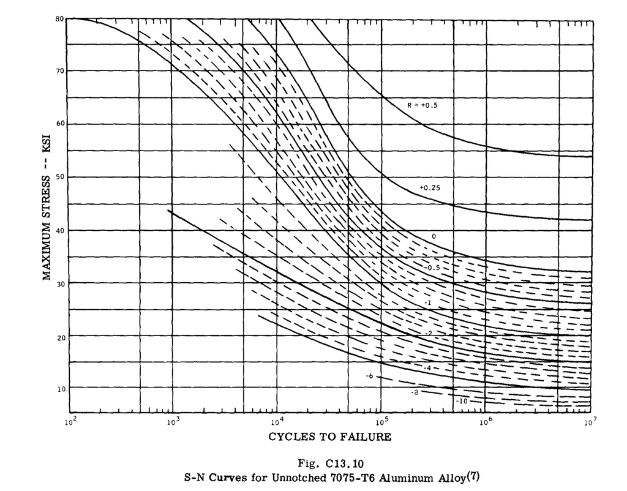

図C13.10 切欠きなし7075-T6アルミニウム合金のS-N曲線 (7)

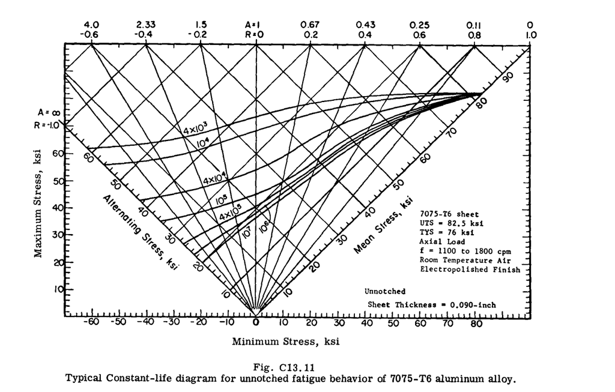

図CI3.11 7075-T6アルミニウム合金の切欠きなし疲労挙動の典型的な一定寿命線図

### C13.3.2 切欠きデータ

切欠きデータは、応力集中の存在下における材料の疲労特性を示すために使用される。これは、同等の集中を有する組立構造物で使用するための比較を提供する。後で詳しく説明する実用寿命予測のために、構造物をいくつかの既知の応力集中係数に設計し、それが同等の応力集中を有する試験片のように振る舞うと仮定することが一般的な実務である。設計の初期段階で実規模の構造コンポーネントのS-N曲線を開発することは通常高価すぎるが、設計のために想定された応力集中の妥当性を判断するために、1点または2点でスポットチェックを行うことが一般的な実務である。これにより、認証が与えられる前に（少なくとも関連する特定のコンポーネントにおいて）、完全な機体に要求される疲労試験に航空機が合格する能力が保証される。

理論的集中係数（ $K_t$ ）が1（切欠きなし）、2.6（中心穴切欠き）、および3.6（小さなラグ）である、軸荷重を受ける7075-T6の試験片のS-N曲線を図C13.12に示す。 $K_t$ の値は純面積の観点から与えられている。試験によって生成された曲線との比較のために、4番目の曲線（ $K_t = 2.6$ に対する理論値）が示されている。ここでは、理論曲線（ $K_t = 1$ に対するS-N曲線を2.6で割ったもの）が、約 $10^7$ サイクルを除いて実験曲線に達しないことがわかる。実験値がより高い理由は、短い寿命範囲において切欠き部での塑性変形によって獲得された有益な残留応力のためであることが一般に認められている。

切欠きなし試験片の曲線（ $K_t = 1$ ）で示される特定の寿命に対する応力を、同じ寿命において切欠き試験片が示す応力で割ると、一般に「疲労ノッチ係数」と呼ばれる係数が得られる。疲労ノッチ係数（ $K_f$ として定義される）

$$K_f = \frac{\text{nominal maximum stress, unnotched specimen}}{\text{nominal maximum stress, notched specimen, same life}}$$

は、通常 $K_t$ よりも低い。しかし、フレッティングが伴う場合には例外が存在する。したがって、長寿命において、小さなラグの $K$ は、幾何学的形状から導き出された理論値3.6ではなく、約5.5であることがわかる。フレッティングとは、圧力下で接触している固体表面の摩擦によって引き起こされる損傷を指す用語である。

上記の比較は、応力集中の効果において、摩擦面が関与しているかどうかに応じて違いがあるという非常に重要な要因を示している。事実上、すべての機械的に締結された継手は「閉じられた切欠きまたはフレッティングに敏感な領域」に分類されるため、単純な切欠きすなわち「開いた集中」とは異なって処理される必要がある。商業用旅客機は、その長寿命の期待から、特にフレッティングに対して敏感である。

切欠きなし疲労データと切欠き疲労データとの比をとることによって求められるすべての応力集中は疲労応力集中であるが、多くの切欠きデータの妥当性は、通常、約 $10^7$ サイクルにおける理論値と比較することによって判断できる。疲労ノッチ係数と理論的応力集中はこの点で等しくなるはずである。そうでない場合、欠陥は切欠きを機械加工することによって生じた残留応力にある可能性がある。鈍いドリルは通常、試験片を本来よりも長持ちさせる残留圧縮応力を導入する。このようなデータは、設計目的には不安全側となる。

上記に対する例外は、非常に鋭い切欠きである。Neuberは、切欠き効果が非常に対象の材料の結晶粒よりも小さくなり得ないという意味で、非常に鋭い場合には切欠き効果が小さくなることを示している。 $(10)$

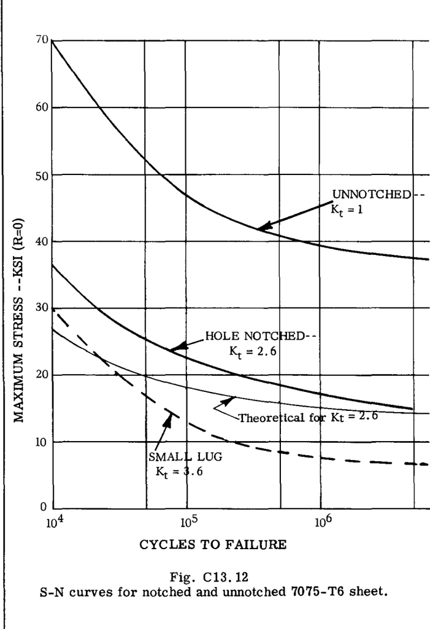

図CI3.12 切欠きおよび切欠きなし7075-T6薄板のS-N曲線

### C13.3.3 疲労限度

疲労限度は、材料が理論上無限の数の応力サイクルに耐えることができる最大応力として定義される。鋼を含む多くの材料は、それ以下では疲労破壊が発生しない明確な応力を示すが、アルミニウムおよび他の多くの合金は特定の疲労限度を持たない。したがって、これらの金属の疲労限度は、200,000,000サイクルの寿命に対応する応力として定義される。

### C13.3.4 疲労試験機

これまで言及されなかった別のタイプのデータは、交番曲げおよび/またはねじりのデータである。鋼に関するほとんどの初期のデータは、試験片を交番曲げでたわませる回転曲げ試験によって取得された。これは、実用荷重が交番曲げであった鉄道車両の車軸の疲労破壊を模擬したものと想定されていた。あいにく、回転曲げ試験は $R = -1$ 以外の応力比での試験には適していない。

J. Goodman $(10)$ は、回転曲げデータを $R = -1$ 以外の応力比に変換するための特別な技術を使用した。図C13.13は、図C13.10のデータを開発するために使用された7075-T6アルミニウム合金試験片のグッドマン線図を示している。この図では、最大、平均、および最小応力が曲線の縦座標であり、横座標は任意の便利な目盛りである。極限引張強さが最初にプロットされ、平均応力の直線がゼロの横座標でそれに引かれる。 $R = -1$ でのサイクリングに対する応力は、適切な寿命（この場合は $10^6$ 、 $10^5$ 、および $10^4$ サイクル）に対して縦軸に沿ってプロットされる。次に、1つの横座標における材料の極限引張強さを表す点に結ぶ線が引かれる。

#### 例 2)

$R = -1$ での $10^4$ サイクルに対する応力は $\pm 51$ KSIである。 $R = 0$ に対する応力を求めよ。

$10^4$ サイクルおよびゼロ応力に対する交点が横座標0.39にあることに注意されたい。最大応力は、同じ横座標において63 KSIであることがわかる。これは、最大応力が73 KSIとして示されている図C13.10の $R = 0$ および $10^4$ サイクルに対するS-N曲線とは一致しない。

ゼロ以外の応力比に対する値は、適切な寿命線の間をスケールで測定し、所望の応力比が見つかるまで右または左に移動することによって推定される。良いディバイダーが役立つ。しかし、より良い方法は、修正グッドマン線図（参照：図C13.11）にデータを再プロットすることである。平均応力線を独立した座標として使用し、最大応力がプロットされる位置に最大応力をプロットし、一定寿命曲線を引く。図C13.11に示す曲線は曲線であるが、これらの曲線は直線になることに注意されたい。図C13.11は、いくつかの応力比に対する実際のデータからプロットされた。両者の間の一致の欠如は、グッドマン線図の信頼性の指標である。

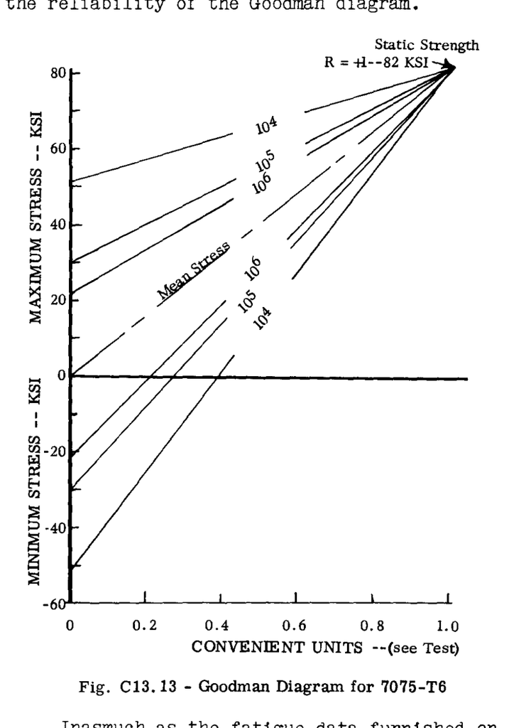

図CI3.13 - 7075-T6のグッドマン線図

鉄鋼会社によって提供される新しい合金の疲労データは、通常（おそらく速度とコストのために）回転曲げ試験からのものであるため、グッドマン線図は間違いなく有用である。しかし、本章の付録に示されているデータを比較することによってわかるように、ある程度の注意が必要である。

多くの軸荷重試験機にはねじり試験用のアダプターがあるが、利用可能なデータはほとんどない。したがって、論理的な手順は、軸方向または曲げの特性をねじりに比例配分することである。表1は、さまざまな材料について、ねじり強度と曲げ疲労強度の比を評価するための実験データを示している。 $(11)$ 曲げからねじりへ変換するための理論的展開は、参考文献12および13に与えられている。しかし、設計目的のためには、引張値の0.5を使用するのが安全であると思われる。

### TABLE 1

### さまざまな材料に対する曲げ疲労強度に対するねじり疲労強度の比

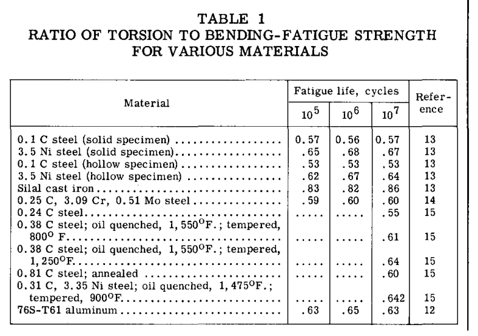

TABLE 1

### C13.3.5 試験のばらつき

試験のばらつきは、長年にわたり疲労の専門家を悩ませてきた問題である。理由の1つは、同一の試験片を用意することが事実上不可能であることである。もう1つは、すべての疲労試験機が、指示される荷重は同じであっても、同じ応答を示すわけではないことである。したがって、図C13.14に示すように散布帯の下部に設計するか、 $(16)$ 計算目的には中央値を使用し、最終設計には散布係数を使用することが一般的な実務である。4の散布係数は、ほとんどの航空機構造物が試験によって実証することを契約上義務付けられている基準である。すなわち、試験構造物は、模擬された実用荷重の4倍の寿命に耐えなければならない。したがって、4000時間の戦闘機は、16,000時間のサービスに等しい時間に耐えなければならない。2の散布係数が使用されるケースもあるが、その場合、散布係数を補償するために荷重の厳しさが通常増加される。

ハンドブックに提示されている疲労データのほとんどすべては、対数中央値または対数平均値である。しかし、本章の付録に示されているデータを比較することによってわかるように、ある程度の注意が必要である。

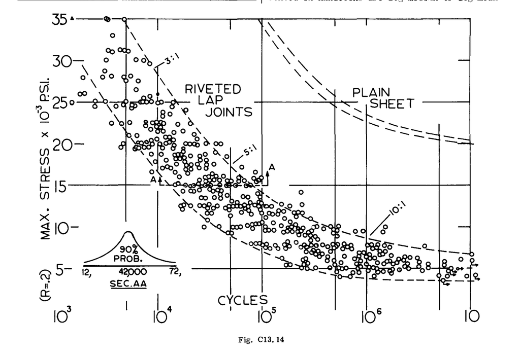

図C13.14 疲労試験のばらつき

設計者は、したがって、ハンドブックのデータを使用する際に、試験のばらつきを許容するために裁量を使用しなければならない。統計学者は、散布データを信頼性に関連付ける標準偏差 $(17)$ （通常、ギリシャ文字の $\sigma$ すなわちシグマで識別される）と呼ばれる係数を使用する。

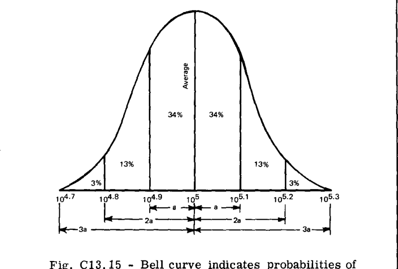

図C13.15 ベル曲線は、 $10^5$ サイクルの平均寿命からの標準偏差に基づく疲労破壊の確率を示す。対数正規分布に基づいて標準偏差は0.1と仮定される。

標準偏差は、試験片の数とデータの広がりを考慮に入れている。パーセンテージの観点から、試験片のグループの99.9%は、平均より $3\sigma$ 低い値を超える寿命を持つことが期待される。例えば、試験片のグループの平均寿命が100,000サイクル（ $10^5$ ）であり、対数正規分布に基づく標準偏差が0.1である場合、いわゆる保証寿命は $10^{(5 - 0.3)} = 10^{4.7}$ となり、そのアンチログは約51,000サイクルである。標準偏差の観点から想定される試験寿命の図を図C13.15に示す。

この例では、標準偏差 $\sigma$ は0.1であるが、これは約 $10^5$ サイクルの寿命に対して良好な値であるためである。さらに、フィラデルフィアの海軍航空工学センター $(18)$ およびオーストラリア、メルボルンの航空宇宙研究研究所 $(19)$ における航空機の実規模試験の平均は、実規模構造物において0.1が $\sigma$ の良好な平均値であることを示している。

標準偏差、すなわちシグマは、破壊までのサイクルが100,000サイクル付近である締結組立品の相対的な優劣を比較する上で非常に重要である。例えば、締結具Aで接合された試験片が、与えられた荷重に対して破壊まで平均100,000サイクルであり、締結具Bを伴う試験片が平均200,000サイクルであると仮定する。締結具Aを伴う試験片の $\sigma$ は0.1である。しかし、締結具Bを伴う試験片のデータにはより多くのばらつきがあるため、平均寿命の対数に基づく標準偏差は0.2である。

それぞれの平均寿命より $3\sigma$ 低い保証最小寿命について、締結具Aを伴う試験片は最小50,000サイクル耐えることが期待できることがわかった。平均寿命が200,000サイクルであるが標準偏差が0.2である締結具Bの場合、200,000の対数は5.3010である。この値から、3 x 0.20（ $3\sigma$ ）を引いて4.7010を得る。そのアンチログは寿命が50,000サイクルであることを示している。これは、100,000サイクルの平均寿命を持つ締結具Aで締結された試験片よりも良くない。

しかし、シグマの値は実際の寿命に大きく依存し、特に小さな切欠きなし試験片において顕著である。寿命が100万サイクルを超える場合、シグマは1以上になることがある。この時点で、寿命に基づく標準偏差の重要性は消失し、他の統計的手法を使用しなければならない。ASTMの特別技術出版物No. STP-91Aは、疲労のための統計の使用に関する情報の良い情報源である。

### C13.3.6 Load-N 曲線

Load-N曲線は、応力が未知である場合によく使用される。通常、破壊強度の割合としてプロットされ、構造物が限界荷重または極限荷重の観点から設計されている点で価値がある。図C13.16は、極限破壊荷重の観点から航空機構造物の寿命を比較したデータを示している。 $(18)$ 示されている構造物はすべて、疲労耐性のための設計が要件ではなかった第二次世界大戦期のものである。現在の疲労要件に合格するものは一つもない。著者は、4000時間のサービス用に設計された航空機に要求される試験に合格するためには、このような構造物が限界荷重（極限の66.7%）において30,000サイクル以上耐えなければならないことを実証した。P51の主翼は、30,000サイクルの寿命に対して極限の40%にしか耐えられないことに注意されたい。

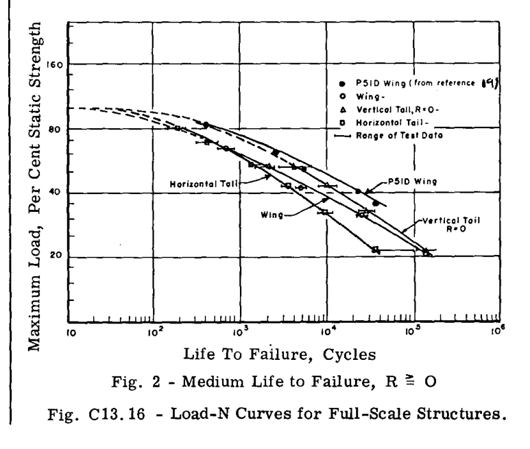

図C13.16 実規模構造物のLoad-N曲線

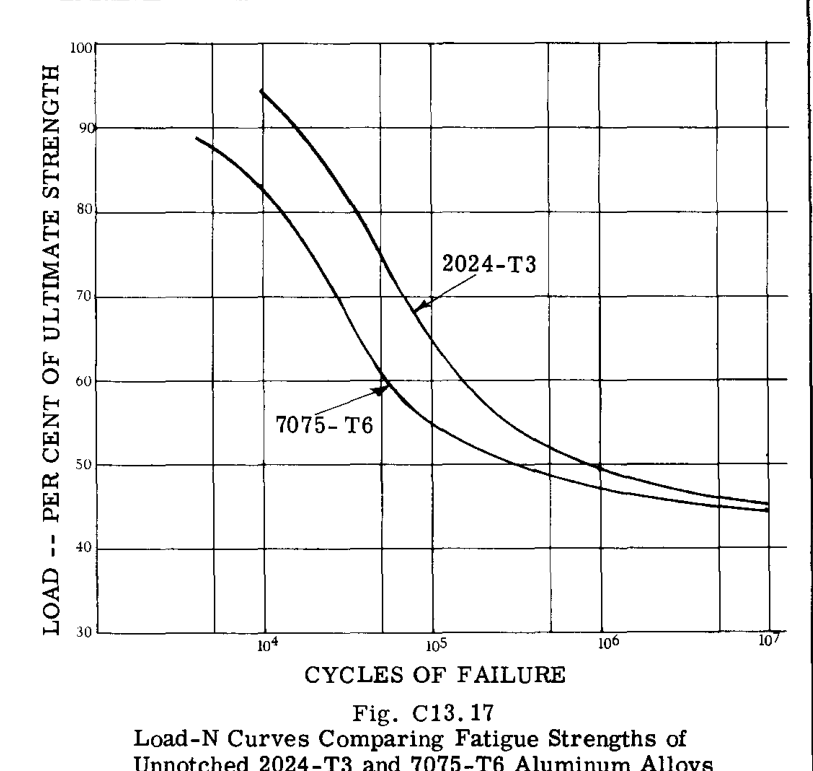

図C13.17 2024-T3および7075-T6アルミニウム合金の切欠きなし疲労強度を比較するLoad-N曲線

図C13.17は、2024-T3および7075-T6アルミニウム合金の切欠きなし試験片の強度を比較するLoad-N曲線である。ここでは、30,000サイクルの寿命に対して、2024-T3（より低い強度の合金）はその極限強度の82%を維持するのに対し、7075-T6（より高い強度の合金）はその極限強度の68%しか維持しないことがわかる。前段と同様に、30,000サイクルの寿命は、4000時間航空機における比較目的の疲労強度指標として使用されている。50,000時間航空機に対する比較は、おそらく異なる寿命で行われるべきである。どの特定の寿命が選択されるかにかかわらず、グラフはなぜ疲労問題がより一般的になってきたかを示しており、より高い強度の合金で設計する際に疲労への特別な強調がなぜ重要であるかを示している。

アルミニウム合金について述べられたことは、鋼についても同様である。しかし、鋼、特に200 ksi以上の強度のものは、疲労寿命を低下させる欠陥に対して脆弱である。

Cummings、Stulen、およびSchulteによって報告された、0.001から0.003インチ径の介在物を有するSAE 4340鋼に関する試験では、200から250 ksiの間で熱処理された材料は、100から150 ksiの間で熱処理された同じ鋼の1/4の寿命しか持たないことが示された。250から300 ksiの間で熱処理されたこの鋼は、さらに短い寿命を持っていた。しかし、介在物が0.00025インチ径よりも小さい場合、疲労強度はその極限強度にほぼ比例していた。

### C13.3.7 高温

金属の高温における疲労特性は、それ自体が研究分野であり、本章の範囲を超えているが、高温特性に関するいくつかの顕著な事実を以下に示す：

1. 寿命に影響を与えるのは温度だけでなく、その温度における時間でもある。付録に示されている6Al-4Vチタン合金の曲線を参照すると、試験は1850 cpmで行われたことがわかる。したがって、データは試験の期間に対して正しい。より長い期間に対しては考慮がなされるべきである。
2. 一般に、静的特性は、高温における疲労特性と同等以上に低下する。これは疲労解析の必要性を無効にするものではないが、静的な考慮によって疲労問題が深刻でなくなる可能性がある。
3. 熱膨張または熱収縮による応力を考慮する必要がある。これらは飛行荷重に対して加算される場合とされない場合がある。
4. クリープと疲労の重畳効果は、現時点では明確に定義されていない。クリープ試験に必要な時間のため、わずかなデータしか入手できない。これらは多かれ少なかれ加速試験で取得されたものである。

## C13.5 疲労耐性の向上

### C13.5.1 はじめに

疲労耐性を向上させる必要性は、今や明らかであるはずである。図C13.2からC13.8に示されている応力集中から予想されるように、疲労による構造破壊のほとんどは、穴、特にせん断荷重を受ける締結具を有する穴において発生する可能性が高い。したがって、各構造継手は、単純な荷重を受けない穴やフィレットアールよりも集中が高い、ピン荷重を受ける一連のラグのように多かれ少なかれ振る舞うことになる。これは、フィレットアールも臨界になり得ないと言っているわけではなく、ここでの要点は、トラブルを探す最初の場所は機械的に締結された継手であるということである。

航空機構造物のほとんどの疲労破壊は締結具の穴で発生しているが、切欠きやフィレットもその損害をもたらしている。あらゆる種類のフィレットにおける応力集中のハンドブック値を見ると、締結具の穴において最初に破壊が発生しないほど不十分なフィレットを持つことは不可能であるように思われる。

せん断荷重を受ける締結具にラグの類似性を使用すると、フィレットにおけるほぼ同数の破壊に対する1つの説明は、荷重が完全に反転されたとしても、荷重を受ける締結具における応力は反転され得ないということである。一方、荷重の反転は、開いた穴やフィレットアールにおける応力を反転させる。これは、引張（A）および圧縮（B）で荷重されたスポンジゴムのラグが、いずれの荷重方向に対してもラグの縁における変形が引張であることを示している図C13.18に示されている。

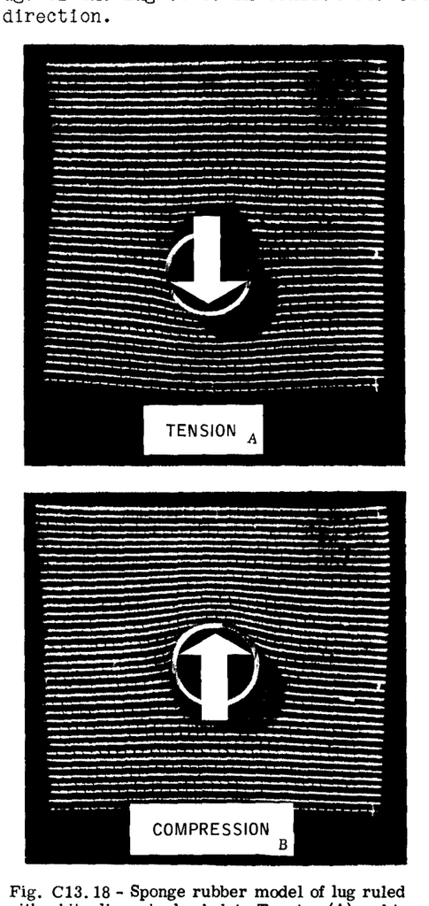

図C13.18 白線が引かれたスポンジゴム製のラグモデルが引張（A）および圧縮（B）で荷重されている。集中部における応力は両方に対して引張応力を引き起こす。

モデルには、荷重が印加されていないときに約0.10インチ離れた白い線が引かれている。圧縮荷重に対する引張応力は、穴から離れた圧縮荷重された材料からのせん断伝達に起因するため、圧縮荷重による引張応力は、直接引張で荷重された場合ほど高くはなり得ない。それにもかかわらず、荷重の完全な反転は、不均等な大きさの2つの引張応力をもたらす。圧縮および引張荷重によるピーク引張応力の位置は互いにわずかにずれており、引張荷重による応力が最も高いため、破壊は常に引張荷重に対する高応力点で発生するはずである。したがって、反転荷重に対する疲労寿命計算に関する限り、圧縮荷重による引張応力は無視できる。しかし、荷重が主に圧縮である場合には、それらを考慮しなければならない。これは、引張-引張および反転荷重を受けた小さなラグの寿命を比較する試験データが提示されている表IIに明確に示されている。反転荷重が引張-引張荷重よりも有害であるという兆候はない。

### 疲労寿命

| 最大総応力 (psi) | 交番荷重 (サイクル) | 0から最大荷重 (サイクル) |
| --- | --- | --- |
| 30,000 | 7,000 9,000 10,000 12,000 | 9,000 10,000 10,000 13,000 |
| 20,000 | 37,000 37,000 42,000 63,000 | 23,000 28,000 29,000 30,000 |

反転荷重および引張-引張荷重を受けた小さなアルミニウム合金製ラグの疲労試験結果をここに示している。反転荷重が引張-引張荷重よりも有害であるという兆候はない。

静的および交番荷重条件下における金属の挙動を、構造物の疲労寿命を向上させるために何ができるかを理解するためにこれから検討する。単純な試験片の静的な応力-ひずみ特性から始めて、切欠きなし試験片のS-Nデータへと続け、切欠きにおける応力の挙動を、切欠きなしの静的および疲労試験片における応力になぞらえて、構造物において何が起こるかを見る。

ほとんどの設計解析は応力の観点から行われるが、変形が与えられた材料の弾性限度を超える場合には、ひずみを考慮することが非常に重要である。

通常、指定された限界荷重条件は塑性変形がないことを想定している。しかし、応力集中において遭遇する可能性のある応力を考慮すると、構造物の寿命中に局所的な塑性変形が全く発生しないように構造物を設計できる可能性は低い。

限界荷重は、少なくとも航空機構造物については、車両の性能を損なうような永久変形なしに耐えることができる作動荷重として定義される。極限荷重は通常、限界荷重の1.5倍として定義される。しかし、この安全率は、それぞれのケースにおける特定の状況に応じて異なる場合がある。

本章の残りの部分における図解例で使用される材料は、航空機構造物においてほぼ普遍的に使用されているため、7075-T6アルミニウム合金とする。ここで関与する原則は他の合金や構造物にも適用されるが、航空機構造物は、その疲労感受性と使用される機械的締結具の数から、主に考慮される。

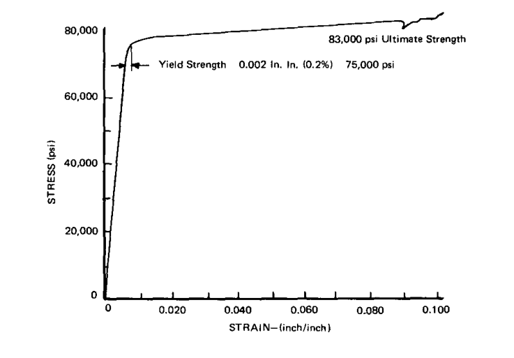

図C13.19 7075-T6アルミニウム合金の応力-ひずみ曲線

### C13.5.2 応力、ひずみ、および塑性変形

7075-T6アルミニウム合金の応力-ひずみ曲線を図C13.19に示す。ここでは、降伏強さが約75 ksiであり、極限破断強さが83 ksiであることがわかる。弾性係数 $E$ は 10,500,000 psi であるが、アルミニウム合金を伴うこれおよび以降の議論においては、きりの良い数値として 10,000,000 psi を使用する。

おそらく、応力集中におけるこの材料の挙動は、応力が全断面積に基づくのではなく、最高応力点における極めて小さな領域に基づいているという点だけが異なり、図C13.19に示すものと非常によく似ている。局所的な降伏が発生すると、応力集中部における小さな領域の増分は追加の荷重を負担することを拒否し（荷重が実際に増加している場合であっても）、応力集中部に隣接する材料が荷重のより大きな部分を負担することを強制される。

集中部における降伏によって荷重を逃がすこの材料の能力は、降伏から生じる残留応力とともに、構造物の他のどの単一の項目よりも疲労強度特性において重要である。

材料のこの挙動をさらに説明するために、応力集中が4であり、平均断面積に基づく限界荷重における応力が25 ksiである構造物を考える。この構造物が、83 ksiの極限強度を持つ脆性材料（7075-T6との比較のため）で造られている場合、4 x 25 ksi = 100 ksi となるため、構造物は破壊する。

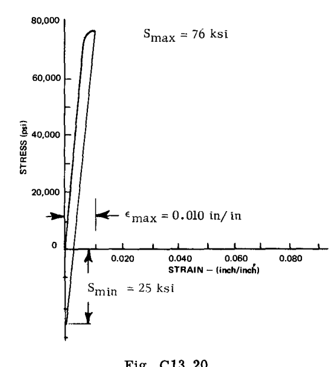

図C13.20 応力集中点におけるひずみの関数としての応力–除荷状態における残留圧縮応力

しかし、構造物が図C13.19に示すような応力-ひずみ特性を持つ7075-T6であった場合、材料は局所的に降伏し、過剰な荷重をまだ降伏していない隣接する材料に伝達する。

明らかに、25 ksiの平均応力は構造物を破壊させないため、局所的な降伏は、降伏した材料と降伏していない材料の耐荷重能力が平均25 ksiになったときに停止しなければならない。これが正確にいつ発生するかは不明であるが、応力集中をひずみ集中とみなすことによって良好な推測を行うことができる。すなわち、25 ksiの公称応力に対応するひずみに4を乗じて集中部における最大ひずみを得て、最大応力は応力-ひずみ曲線から求められる。 $E = 10 \times 10^6$ psi と仮定すると、以下が得られる：

$$\varepsilon_{\text{nom}} = \frac{25,000}{10,000,000} = 0.0025 \text{ in/in}$$

および

$$\varepsilon_{\max} = 4 \times 0.0025 = 0.010 \text{ in/in}$$

図C13.19から、 $S_{\max} = 76 \text{ ksi}^*$ となる。

- ksiやpsiのような単位は、ここでは用語のために混在している。ほとんどのS-Nデータはksiで与えられているが、10万ksiではなく $E = 10$ million psi と言う。

局所的に降伏したため、局所的な材料は現在、残りの部分よりも長くなっている。したがって、構造物が除荷されると、この永久に伸びた材料は、ゼロひずみの元の位置に戻ろうとする比較的大きなバルクの材料によって圧縮されることを強制される。この状態に対する類似性は、古いコルクをボトルに戻そうとするようなものである。降伏した材料の面積が残りの材料の面積に比べて非常に小さい場合、明らかな永久歪みは生じない。しかし、図C13.20にグラフィカルに示されているように、25 ksiの残留応力が生じる。

引張変形を増加させると、永久歪みの量が大きくなり、それに対応して残留応力の値も大きくなる。しかし、先行する引張荷重がどれほど高くても、材料の圧縮降伏を超える残留応力を導入することは考えられない。仮に、より大きな量を導入することが可能であったとしても、時間が経てば残留応力は圧縮降伏以下の値に緩和する。実際の保持可能な値は知られていない。しかし、ショットピーニング業界における経験は、圧縮降伏強さの最大3分の2を室温において無期限に維持できることを示している。

広い板の穴におけるひずみの測定は、塑性状態に達した後にひずみ速度が増加することを示している。 $(21)$ これは、想定されているよりもさらに大きな量の残留応力を暗示している。しかし、ひずみが大きくなると、 $\frac{\text{plastic}}{\text{elastic}}$ 面積の比が増加するため、除荷時にひずみはゼロに戻らない。したがって、線形仮定は、残留応力を推定するために使用される場合、多かれ少なかれ互いに相殺し合う2つの誤差を内包している。 $(22)$

線形ひずみ概念の精度はこの時点では論争の的ではないが、高い予荷重の後に集中部において何らかの残留圧縮応力が存在することを実証している。逆に、圧縮で降伏した後は、残留引張応力が存在することが予想される。これはまた、なぜいくつかの疲労破壊が「圧縮荷重のみ」を受ける構造物において発生するのかを説明している。これについては後で詳しく説明する。

### C13.5.3 残留応力の疲労への影響

応力集中点における閉じ込められた残留応力は、予荷重された構造物を、局所的な降伏点まで荷重されたことのない構造物とは異なる方法で挙動させる。

例えば、集中部における応力を0から60 ksiにするような荷重であった場合、予荷重によって $-30$ ksi の残留圧縮応力が生じた場所では、バージン構造において以前に0から60 ksiの応力を引き起こした荷重は、予荷重された構造において $\pm 30$ ksi をもたらすことが予想される。このような構造物の元の寿命は25,000サイクル（図C13.10参照、 $S_{\max} = 60$ ksi、 $R = 0$ ）であるが、予荷重された構造物は100,000サイクル（図C13.10参照、 $S_{\max} = 30$ ksi、 $R = -1$ ）持続する。

同様に、予荷重が $-40$ ksi の残留応力を残すようなものであった場合、 $R = 0$ でのサイクリングに対する寿命は200,000サイクル（図C13.10参照、 $S_{\max} = -2$ ）であることがわかる。 $R$ の定義は $S_{\min}/S_{\max}$ であり、マイナス符号であるため、 $-40$ ksi の応力は、数値的には大きくても、 $+20$ ksi の応力よりも低い。したがって、 $-10$ またはマイナス無限大の応力比を持つことができる。上記の計算を図C13.21にグラフィカルに示す。

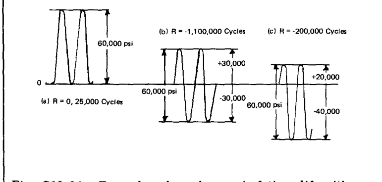

図C13.21 集中部における残留応力の追加による疲労寿命の変化を示す例。すべての試験片は、60,000 psiの応力範囲を生じさせる同じ荷重でサイクルされている。

### C13.5.4 機械的に導入された残留応力

上記の議論では、圧縮残留応力は局所的な降伏を引き起こすために過荷重をかけることによって導入された。しかし、好ましい残留応力を獲得するための他の多くの方法があり、おそらく最もよく知られているのはショットピーニングである。その名が示すように、ピーニングは、関連する表面をブラストする空気圧下の小さな丸いショットによって達成される。ピーニングされる部品は、使用済みのショットをトラップしてリザーバーに戻すエンクロージャ内に配置される。特別な機械アームまたはゴム製のアームプロテクターにより、ピーニングされる部品をハンドリングすることができる。

ショットのサイズは0.007から0.175インチ径の範囲である。大きなショットサイズは圧縮応力の深い層を生成するために使用され、小さなショットサイズは小さなアールに到達するために使用される。速度は100から200 ft/secの範囲である。

ショットピーニングの目的は表面に圧縮材料の層を得ることであるため、完全性は、ショットの痕のカバー率によって視覚的にチェックされる。しかし、ピーニングは、ショットがピーニングされる表面よりも硬くない場合であっても機能し、その場合は目に見えるディンプルを残さないことがある。これらの困難を克服するために、Almen $(23)$ ゲージが使用される。Almenゲージは、片面をショットピーニングすると金属がピーニングされた側にハンプを生じるスチール（硬度 47 $R_c$ ）のストリップにすぎない。Almen強度は、単にダイヤルインジケータで測定されたストリップの弧の高さである。したがって、12-14 Almen Aの強度は、Aストリップ（厚さ0.051インチ）の弧の高さが0.012から0.014インチであることを意味する。

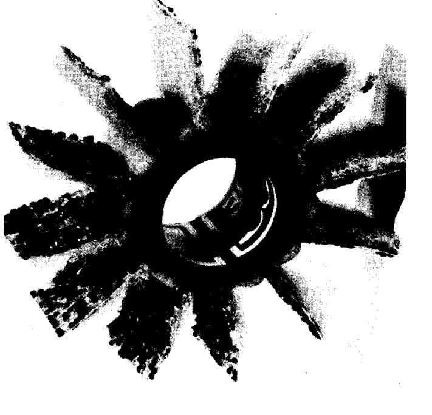

図C13.23は、2つのピーニング方法によって得られた残留応力を比較している。2つの明確な曲線が示されているが、データは実際の差が存在することを統計的に決定するには不十分である。ショットピーニング業界全体で、より激しいブラストを伴う不完全なカバー率は、より低い強度でより大きなカバー率を伴う場合と同じ強度をもたらすことが知られている。しかし、この例における2つのピーニングされた表面の視覚的検査は、両方のケースにおいて完全なカバー率を示した。

- 3M Co., St. Paul, Minnesota によるピーニングシステムの商標名。

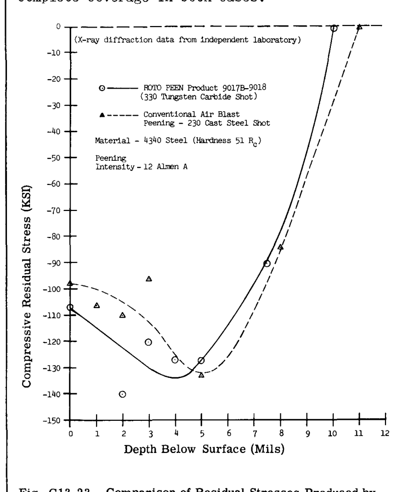

図C13.23 2つのピーニング方法によって生成された残留応力の比較

ショットピーニングは、有益な残留圧縮応力を獲得するための最も一般的な方法であると思われるが、残留応力を提供する他の方法には、「ベアリング加工（bearingizing）」、「コイニング（coining）」、および冷間圧延がある。ベアリング加工は、Cogsdill Tool Products, Inc.によって使用されている商標名である。この方法は、処理される穴に、密着する表面ローラーを備えたシャフトを挿入することからなる。これにより、穴の側面にバニッシュ効果が生じる。

コイニング $(26)$ は、保護される穴または開口部の周囲に同心円状の溝をプレスすることからなる。これにより、穴に隣接する材料が内側に絞られ、穴の直径が減少し、残留圧縮応力の量はコインの深さに依存する。一般に、アールが大きいほど、残留応力は大きくなる。